# DS 10: Regression in Political Science Using R

Simple, Multiple, and Multivariate Regression

Suchir Kalra

# 🗳️ Regression & Voting Behavior

We are going to try to examine the relationship between Literacy Rate & Voter Turnout through:

- Simple Linear Regression
- Multiple Linear Regression
- Multivariate Regression
- Understanding Controls & Coefficients
- Fixed Effects - District & Time

# 🔧 Simulating Political Science Data in R (This creates a random dataset! Don’t trust this data! It’s self created)

```r
set.seed(123)

# Simulate panel data: 10 districts over 5 years
districts <- paste0("D", 1:10)
years <- 2015:2019
panel_data <- expand.grid(district = districts, year = years)

# Add variables
panel_data$literacy_rate <- round(runif(nrow(panel_data), 60, 95), 1)
panel_data$urbanization <- round(runif(nrow(panel_data), 30, 90), 1)
panel_data$median_income <- round(rnorm(nrow(panel_data), 50000, 10000), 0)
panel_data$internet_access <- round(runif(nrow(panel_data), 20, 80), 1)

# Generate outcome with district and year effects
district_effects <- rnorm(length(districts), 0, 5)
names(district_effects) <- districts

year_effects <- rnorm(length(years), 0, 2)
names(year_effects) <- years

panel_data$voter_turnout <- 40 +
  0.2 * panel_data$literacy_rate +
  0.05 * panel_data$internet_access +
  district_effects[panel_data$district] +
  year_effects[as.character(panel_data$year)] +
  rnorm(nrow(panel_data), 0, 3)

panel_data$partyA_share <- 30 +
  0.3 * panel_data$literacy_rate +        # Party A does well where literacy is higher
  -0.2 * panel_data$urbanization +        # Maybe weaker in urban areas
  0.01 * panel_data$median_income +       # Slightly better in richer districts
  0.1 * panel_data$internet_access +      # More popular in digitally connected areas
  rnorm(nrow(panel_data), mean = 0, sd = 5)  # Add random noise

head(panel_data)
```

```
##   district year literacy_rate urbanization median_income internet_access
## 1       D1 2015          70.1         32.7         52533            34.3
## 2       D2 2015          87.6         56.5         49715            77.7
## 3       D3 2015          74.3         77.9         49571            56.1
## 4       D4 2015          90.9         37.3         63686            50.9
## 5       D5 2015          92.9         63.7         47742            44.2
## 6       D6 2015          61.6         42.4         65165            72.8
##   voter_turnout partyA_share
## 1      56.84328     574.3222
## 2      64.05801     548.2766
## 3      55.60105     538.5029
## 4      53.63439     687.2832
## 5      57.89153     520.4160
## 6      63.85271     708.9161
```

## Simple Linear Regression Model

```r
model_simple <- lm(voter_turnout ~ literacy_rate, data = panel_data)

print(summary(model_simple))
```

```
##
## Call:
## lm(formula = voter_turnout ~ literacy_rate, data = panel_data)
##
## Residuals:
##      Min       1Q   Median       3Q      Max
## -13.7698  -3.4221   0.6827   4.2919  10.1308
##
## Coefficients:
##               Estimate Std. Error t value Pr(>|t|)
## (Intercept)   39.45858    6.32506   6.238 1.08e-07 ***
## literacy_rate  0.23155    0.08021   2.887  0.00582 **
## ---
## Signif. codes:  0 '***' 0.001 '**' 0.01 '*' 0.05 '.' 0.1 ' ' 1
##
## Residual standard error: 5.779 on 48 degrees of freedom
## Multiple R-squared:  0.1479, Adjusted R-squared:  0.1302
## F-statistic: 8.334 on 1 and 48 DF,  p-value: 0.005817
```

```r
stargazer(model_simple, report = "vcp",          # v = coefficient, c = p-value, p = significance stars
          p.auto = TRUE, type = "text")
```

```
##
## ===============================================
##                         Dependent variable:
##                     ---------------------------
##                            voter_turnout
## -----------------------------------------------
## literacy_rate                  0.232
##                              p = 0.006
##
## Constant                      39.459
##                             p = 0.00000
##
## -----------------------------------------------
## Observations                    50
## R2                             0.148
## Adjusted R2                    0.130
## Residual Std. Error       5.779 (df = 48)
## F Statistic            8.334*** (df = 1; 48)
## ===============================================
## Note:               *p<0.1; **p<0.05; ***p<0.01
```

## Visualising Simple Regression

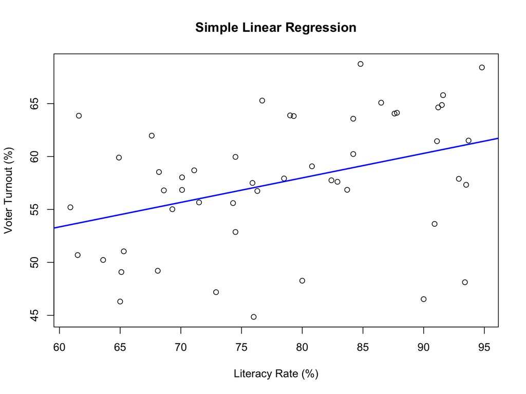

```r
plot_simple <- plot(panel_data$literacy_rate, panel_data$voter_turnout,
     xlab = "Literacy Rate (%)", ylab = "Voter Turnout (%)",
     main = "Simple Linear Regression")
abline(model_simple, col = "blue", lwd = 2)
```

## Adding Controls to linear regression

```r
model_controls <- lm(voter_turnout ~ literacy_rate + urbanization + median_income + internet_access,
                     data = panel_data)

summary(model_controls, type = "text")
```

```
##
## Call:
## lm(formula = voter_turnout ~ literacy_rate + urbanization + median_income +
##     internet_access, data = panel_data)
##
## Residuals:
##     Min      1Q  Median      3Q     Max
## -13.218  -3.869   1.103   3.560  10.674
##
## Coefficients:
##                   Estimate Std. Error t value Pr(>|t|)
## (Intercept)      3.644e+01  9.203e+00   3.960 0.000264 ***
## literacy_rate    2.285e-01  8.252e-02   2.769 0.008146 **
## urbanization     4.138e-02  5.233e-02   0.791 0.433204
## median_income    3.277e-05  9.391e-05   0.349 0.728709
## internet_access -1.689e-02  5.305e-02  -0.318 0.751708
## ---
## Signif. codes:  0 '***' 0.001 '**' 0.01 '*' 0.05 '.' 0.1 ' ' 1
##
## Residual standard error: 5.903 on 45 degrees of freedom
## Multiple R-squared:  0.1665, Adjusted R-squared:  0.09241
## F-statistic: 2.247 on 4 and 45 DF,  p-value: 0.07884
```

```r
stargazer(model_simple, model_controls, report = "vcp",          # v = coefficient, c = p-value, p = significance stars
          p.auto = TRUE, type = "text")
```

```
##
## =============================================================
##                                Dependent variable:
##                     -----------------------------------------
##                                   voter_turnout
##                              (1)                  (2)
## -------------------------------------------------------------
## literacy_rate               0.232                0.228
##                           p = 0.006            p = 0.009
##
## urbanization                                     0.041
##                                                p = 0.434
##
## median_income                                   0.00003
##                                                p = 0.729
##
## internet_access                                 -0.017
##                                                p = 0.752
##
## Constant                   39.459               36.445
##                          p = 0.00000          p = 0.0003
##
## -------------------------------------------------------------
## Observations                 50                   50
## R2                          0.148                0.166
## Adjusted R2                 0.130                0.092
## Residual Std. Error    5.779 (df = 48)      5.903 (df = 45)
## F Statistic         8.334*** (df = 1; 48) 2.247* (df = 4; 45)
## =============================================================
## Note:                             *p<0.1; **p<0.05; ***p<0.01
```

What happens to the R2 Score?

R² will always increase when you add more variables — but that doesn’t always mean your model is better. That’s why we check Adjusted R² too. Good for understanding overall model fit but can be inflated by adding more variables, regardless of their true impact.

## Multivariate Regression

This fits two separate linear models internally: voter_turnout ~ literacy_rate + … & partyA_share ~ literacy_rate + …

```r
Y <- cbind(panel_data$voter_turnout, panel_data$partyA_share)
X <- as.matrix(panel_data[, c("literacy_rate", "urbanization", "median_income", "internet_access")])

model_multi <- lm(Y ~ X)

summary(model_multi)
```

```
## Response Y1 :
##
## Call:
## lm(formula = Y1 ~ X)
##
## Residuals:
##     Min      1Q  Median      3Q     Max
## -13.218  -3.869   1.103   3.560  10.674
##
## Coefficients:
##                    Estimate Std. Error t value Pr(>|t|)
## (Intercept)       3.644e+01  9.203e+00   3.960 0.000264 ***
## Xliteracy_rate    2.285e-01  8.252e-02   2.769 0.008146 **
## Xurbanization     4.138e-02  5.233e-02   0.791 0.433204
## Xmedian_income    3.277e-05  9.391e-05   0.349 0.728709
## Xinternet_access -1.689e-02  5.305e-02  -0.318 0.751708
## ---
## Signif. codes:  0 '***' 0.001 '**' 0.01 '*' 0.05 '.' 0.1 ' ' 1
##
## Residual standard error: 5.903 on 45 degrees of freedom
## Multiple R-squared:  0.1665, Adjusted R-squared:  0.09241
## F-statistic: 2.247 on 4 and 45 DF,  p-value: 0.07884
##
##
## Response Y2 :
##
## Call:
## lm(formula = Y2 ~ X)
##
## Residuals:
##    Min     1Q Median     3Q    Max
## -6.373 -3.273 -1.446  3.350 11.057
##
## Coefficients:
##                    Estimate Std. Error t value Pr(>|t|)
## (Intercept)       2.487e+01  7.551e+00   3.294  0.00193 **
## Xliteracy_rate    3.080e-01  6.770e-02   4.549 4.06e-05 ***
## Xurbanization    -2.130e-01  4.294e-02  -4.960 1.05e-05 ***
## Xmedian_income    1.009e-02  7.705e-05 130.935  < 2e-16 ***
## Xinternet_access  1.102e-01  4.353e-02   2.531  0.01495 *
## ---
## Signif. codes:  0 '***' 0.001 '**' 0.01 '*' 0.05 '.' 0.1 ' ' 1
##
## Residual standard error: 4.843 on 45 degrees of freedom
## Multiple R-squared:  0.9974, Adjusted R-squared:  0.9972
## F-statistic:  4355 on 4 and 45 DF,  p-value: < 2.2e-16
```

# 🧱 Why District and Year Fixed Effects?

### ✅ District Fixed Effects

Districts differ in many **time-invariant** ways that may affect voter turnout:

- Historical political culture
- Local party strength
- Literacy history
- Urban/rural composition
- Caste/class balance

We may not observe all of these factors directly. But if they **don’t change much over time**, we can **control for them** using *district fixed effects*.

This helps isolate the effect of variables like literacy or internet access **within each district over time**.

### 🕒 Year Fixed Effects

Election years bring **common national shocks**:

- National party wave (e.g., Modi wave in 2014)
- Economic events (e.g., demonetization)
- Election Commission policies
- COVID-related disruptions

Year fixed effects soak up **anything that affects all districts equally in a given year**, so we don’t mistakenly attribute it to our variables of interest.

### 🧪 Together: District + Year FE

By including **both**, our model asks:

> “Within a given district, when literacy or internet access increases, does turnout change — accounting for anything constant about that district and anything affecting all districts that year?”

```r
library(lfe)

# No fixed effects
model_felm_simple <- felm(voter_turnout ~ literacy_rate + internet_access | 0, data = panel_data)

stargazer(model_felm_simple, report = "vcp",          # v = coefficient, c = p-value, p = significance stars
          p.auto = TRUE, type = "text")
```

```
##
## ===============================================
##                         Dependent variable:
##                     ---------------------------
##                            voter_turnout
## -----------------------------------------------
## literacy_rate                  0.231
##                              p = 0.007
##
## internet_access               -0.025
##                              p = 0.628
##
## Constant                      40.766
##                             p = 0.00000
##
## -----------------------------------------------
## Observations                    50
## R2                             0.152
## Adjusted R2                    0.116
## Residual Std. Error       5.825 (df = 47)
## ===============================================
## Note:               *p<0.1; **p<0.05; ***p<0.01
```

```r
# District fixed effects
model_felm_district <- felm(voter_turnout ~ literacy_rate + internet_access | district, data = panel_data)

stargazer(model_felm_district, report = "vcp",          # v = coefficient, c = p-value, p = significance stars
          p.auto = TRUE, type = "text")
```

```
##
## ===============================================
##                         Dependent variable:
##                     ---------------------------
##                            voter_turnout
## -----------------------------------------------
## literacy_rate                  0.287
##                             p = 0.00003
##
## internet_access               -0.024
##                              p = 0.550
##
## -----------------------------------------------
## Observations                    50
## R2                             0.692
## Adjusted R2                    0.603
## Residual Std. Error       3.903 (df = 38)
## ===============================================
## Note:               *p<0.1; **p<0.05; ***p<0.01
```

```r
#Year fixed effects
model_felm_year <- felm(voter_turnout ~ literacy_rate + internet_access | year, data = panel_data)

stargazer(model_felm_year, report = "vcp",          # v = coefficient, c = p-value, p = significance stars
          p.auto = TRUE, type = "text")
```

```
##
## ===============================================
##                         Dependent variable:
##                     ---------------------------
##                            voter_turnout
## -----------------------------------------------
## literacy_rate                  0.176
##                              p = 0.033
##
## internet_access               -0.008
##                              p = 0.868
##
## -----------------------------------------------
## Observations                    50
## R2                             0.325
## Adjusted R2                    0.231
## Residual Std. Error       5.433 (df = 43)
## ===============================================
## Note:               *p<0.1; **p<0.05; ***p<0.01
```

```r
# District + year fixed effects
model_felm_district_year <- felm(voter_turnout ~ literacy_rate + internet_access | district + year, data = panel_data)

stargazer(model_felm_district_year, report = "vcp",          # v = coefficient, c = p-value, p = significance stars
          p.auto = TRUE, type = "text")
```

```
##
## ===============================================
##                         Dependent variable:
##                     ---------------------------
##                            voter_turnout
## -----------------------------------------------
## literacy_rate                  0.230
##                             p = 0.00003
##
## internet_access               -0.005
##                              p = 0.866
##
## -----------------------------------------------
## Observations                    50
## R2                             0.851
## Adjusted R2                    0.785
## Residual Std. Error       2.871 (df = 34)
## ===============================================
## Note:               *p<0.1; **p<0.05; ***p<0.01
```

```r
stargazer(model_felm_simple,model_felm_district,model_felm_district_year, column.labels = c("simple", "district fixed effects", "district + time fixed effects"), report = "vcp", p.auto = TRUE, type = "text")
```

```
##
## ========================================================================================
##                                             Dependent variable:
##                     --------------------------------------------------------------------
##                                                voter_turnout
##                         simple      district fixed effects district + time fixed effects
##                           (1)                (2)                        (3)
## ----------------------------------------------------------------------------------------
## literacy_rate            0.231              0.287                      0.230
##                        p = 0.007         p = 0.00003                p = 0.00003
##
## internet_access         -0.025              -0.024                    -0.005
##                        p = 0.628          p = 0.550                  p = 0.866
##
## Constant                40.766
##                       p = 0.00000
##
## ----------------------------------------------------------------------------------------
## Observations              50                  50                        50
## R2                       0.152              0.692                      0.851
## Adjusted R2              0.116              0.603                      0.785
## Residual Std. Error 5.825 (df = 47)    3.903 (df = 38)            2.871 (df = 34)
## ========================================================================================
## Note:                                                        *p<0.1; **p<0.05; ***p<0.01
```

## Note Stargazer can typically handle 3 models in one table. Hence, we can use model summary library for a broad summary.

```r
library(modelsummary)

modelsummary(
  list(
    "Simple OLS" = model_felm_simple,
    "District FE" = model_felm_district,
    "Year FE" = model_felm_year,
    "District + Year FE" = model_felm_district_year
  ),
  output = "markdown",   # or "html" for slides
  statistic = "p.value"  # shows p-values instead of SEs
)
```

|  | Simple OLS | District FE | Year FE | District + Year FE |
| --- | --- | --- | --- | --- |
| (Intercept) | 40.766 |  |  |  |
|  | (<0.001) |  |  |  |
| literacy_rate | 0.231 | 0.287 | 0.176 | 0.230 |
|  | (0.006) | (<0.001) | (0.032) | (<0.001) |
| internet_access | -0.025 | -0.024 | -0.008 | -0.005 |
|  | (0.628) | (0.549) | (0.868) | (0.865) |
| Num.Obs. | 50 | 50 | 50 | 50 |
| R2 | 0.152 | 0.692 | 0.325 | 0.851 |
| R2 Adj. | 0.116 | 0.603 | 0.231 | 0.785 |
| AIC | 323.0 | 290.3 | 319.6 | 262.1 |
| BIC | 330.7 | 315.2 | 334.9 | 294.6 |
| RMSE | 5.65 | 3.40 | 5.04 | 2.37 |